# Dates and Times with `lubridate`

### Practice (required)

**Question #4**: The [2015 Boston Marathon](https://en.wikipedia.org/wiki/2015_Boston_Marathon) took place on April 20th, 2015. It was the 119th running of one of the world’s most well-known races. The data below contain information, results, and splits for each finisher:

```r
marathon = read.csv("https://remiller1450.github.io/data/BostonMarathon2015.csv")
```

**Part A**: A marathon is approximately 26.2 miles, making the first half 13.1 miles. Using this information, calculate the per mile pace (in seconds) for each participant in the *first half of the race*. Be sure to store your results.

**Part B**: Now calculate the pace per mile in the *second half of the race*. Be sure to store your results.

**Part C**: Now create a scatterplot displaying the relationship between pace per mile in the first half of the race vs. pace per mile in the second half of the race by age and sex. To facilitate this, you should assemble your results from Parts A and B into a data frame that also includes the “Age” and “M.F” columns from the original data. A target graphic is given below. *Note*: `scale_x_time()` and `scale_y_time()` can be used to display your first half and second half paces on a time scale. The graph shown below uses the argument `alpha = 0.2` to reduce the impact of over-plotting, and a 45-degree line is added using `geom_abline()`.

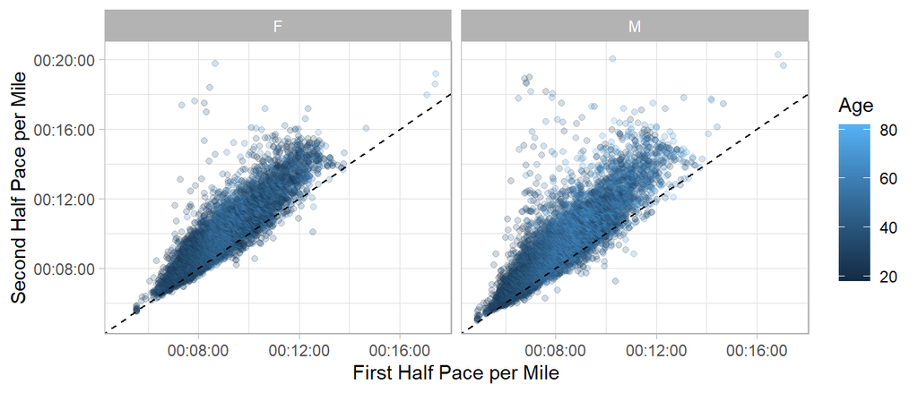

$~$

### Practice (optional, for extra credit)

**Question #5**: The two CSV files below contain results from a real experiment on cannabis impaired driving conducted in an advanced driving simulator. The file “startdose.csv” is a list of participant IDs and the time at which each began a 10-min *ad libitum* dose of inhaled cannabis, and the file “high_effects.csv” records each participant’s self-reported feelings of “high” (on a 0-100 scale) at various points throughout the experiment.

```r
dose = read.csv("https://remiller1450.github.io/data/startdose.csv")
high = read.csv("https://remiller1450.github.io/data/high_effects.csv")
```

Your task in this question is to recreate the visualization below:

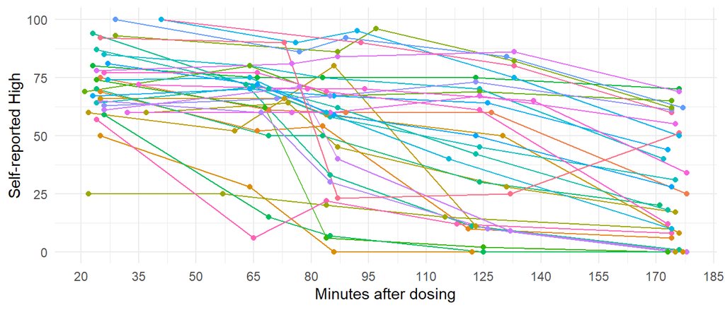